# Research Analysis Notebook

Authors

Affiliations

[Aaron Gullickson](https://aarongullickson.netlify.app/)

University of Oregon

Jenifer Bratter

Rice University

This research notebook analyzes the data and models estimated for multiracial intermarriage.

```r
get_coefs <- function(x) {
  temp <- coef(x)[,c(1,2)]
  return(tibble(variable=rownames(temp), coef=temp[,1], se=temp[,2]))
}

coef_short_sym <- get_coefs(model_short_sym) |>
  filter(str_detect(variable, "race_exog")) |>
  mutate(variable=str_replace(variable, "race_exog_short_sym",""))

coef_short_asym <- get_coefs(model_short_asym) |>
  filter(str_detect(variable, "race_exog_short_asym")) |>
  mutate(variable=str_replace(variable, "race_exog_short_asym",""))

coef_full <- get_coefs(model_full_sym_multi) |>
  filter(str_detect(variable, "race_exog_full")) |>
  mutate(variable=str_replace(variable, "race_exog_full_sym",""))

coef_multi <- coef_short_sym |>
  filter(str_detect(variable, "Multi/Multi"))
```

# Basic Sample Information

```r
race_order <- c("White", "Black", "Asian", "Indigenous", "Latino",
                "White-Indigenous", "White-Asian", "White-Black",
                "Black-Indigenous", "Black-Asian", "Asian-Indigenous")

unions <- unions |>
  mutate(raceh = factor(raceh, race_order),
         racew = factor(racew, race_order))

male_alt <- male_alt |>
  mutate(raceh = factor(raceh, race_order))

female_alt <- female_alt |>
  mutate(racew = factor(racew, race_order))

tbl_counts <- unions |>
  count(raceh) |>
  rename(race = raceh, n_union_h = n)
tbl_counts <- unions |>
  count(racew) |>
  rename(race = racew, n_union_w = n) |>
  full_join(tbl_counts)
tbl_counts <- male_alt |>
  count(raceh) |>
  rename(race = raceh, n_alt_h =n) |>
  full_join(tbl_counts)
tbl_counts <- female_alt |>
  count(racew) |>
  rename(race = racew, n_alt_w =n) |>
  full_join(tbl_counts) |>
  select(race, n_union_w, n_union_h, n_alt_w, n_alt_h)
tbl_counts |>
  gt(rowname_col = "race") |>
  fmt_integer(starts_with("n_")) |>
  cols_label(
    race = "Race",
    n_union_w = "Wife",
    n_union_h = "Husband",
    n_alt_w = "Women",
    n_alt_h = "Men"
  ) |>
  cols_align(race, align = "left") |>
  tab_spanner(
    label = "Marriages",
    columns = starts_with("n_union_")
  ) |>
  tab_spanner(
    label = "Alternates",
    columns = starts_with("n_alt_")
  ) |>
  grand_summary_rows(fns = list(list(label = "Total", fn = "sum")),
                     fmt = ~ fmt_integer(.))
```

Table 1: Number of spouses and alternate spouses by sex and race from American Community Survey Data, 2010-2019.

|  | Marriages Wife | Marriages Husband | Alternates Women | Alternates Men |
| --- | --- | --- | --- | --- |
| White | 607,851 | 611,462 | 4,145,979 | 3,524,686 |
| Black | 52,178 | 60,647 | 928,698 | 725,355 |
| Asian | 34,638 | 26,738 | 244,873 | 199,473 |
| Indigenous | 7,664 | 7,503 | 73,275 | 67,826 |
| Latino | 114,115 | 111,099 | 806,054 | 750,814 |
| White-Indigenous | 4,737 | 4,446 | 36,251 | 34,845 |
| White-Asian | 4,491 | 3,923 | 24,644 | 24,731 |
| White-Black | 2,616 | 2,544 | 24,628 | 21,938 |
| Black-Indigenous | 424 | 481 | 7,719 | 6,891 |
| Black-Asian | 351 | 323 | 3,093 | 2,667 |
| Asian-Indigenous | 420 | 319 | 3,117 | 3,083 |
| Total | 829,485 | 829,485 | 6,298,331 | 5,362,309 |

```r
male_alt |>
  bind_rows(female_alt) |>
  mutate(market_type = factor(str_sub(mar_market, 1, 1),
                              levels = c("M", "C", "P"),
                              labels = c("Metro Area", "County", "PUMA"))) |>
  group_by(market_type) |>
  summarize(n = n()) |>
  ungroup() |>
  mutate(prop = n / sum(n)) |>
  gt() |>
  cols_label(market_type ~ "Type of marriage market",
             n ~ "N",
             prop ~ "Percent") |>
  fmt_number(n, decimals = 0) |>
  fmt_percent(prop, decimals = 1)
```

Table 2: Distribution of marriage market type for all alternate partners

| Type of marriage market | N | Percent |
| --- | --- | --- |
| Metro Area | 8,669,324 | 74.3% |
| County | 301,452 | 2.6% |
| PUMA | 2,689,864 | 23.1% |

# Raw differences in partner selection

We begin by just looking at the raw differences in partner selection among multiracial respondents.

```r
couples <- mar_markets[[1]] |> filter(choice)

husbands <- couples |>
  mutate(race_ego=raceh,
         race_spouse=racew,
         gender="husband") |>
  select(race_ego, race_spouse, gender)
wives <- couples |>
  mutate(race_ego=racew,
         race_spouse=raceh,
         gender="wife") |>
  select(race_ego, race_spouse, gender)

partner_choice <- bind_rows(husbands, wives) |>
  mutate(race_spouse=factor(race_spouse,
                            levels=c("White","Black","Indigenous","Asian",
                                     "Latino","White-Black","White-Indigenous",
                                     "White-Asian","Black-Indigenous",
                                     "Black-Asian","Asian-Indigenous")))
```

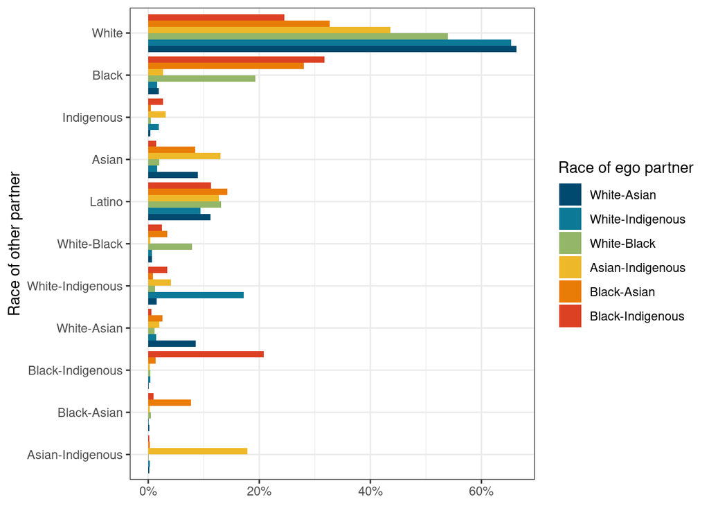

Figure 1: Distribution of other partner’s race for multiracial respondents

```r
partner_choice |>
  filter(str_detect(race_ego, "-")) |>
  mutate(race_ego=factor(race_ego,
                         levels=c("White-Asian","White-Indigenous","White-Black",
                                  "Asian-Indigenous","Black-Asian","Black-Indigenous"))) |>
  ggplot(aes(x=fct_rev(race_spouse), y=after_stat(prop), group=race_ego,
             fill=race_ego))+
  geom_bar(position="dodge")+
  scale_y_continuous(labels=scales::percent)+
  scale_fill_manual(values = pnw_palette("Bay", 6))+
  labs(x="Race of other partner", y=NULL, fill="Race of ego partner")+
  coord_flip()+
  theme_bw()
```

Unsurprisingly, for all but one multiracial group (Black/Indigenous) the most common partner race is White, which is primarily a function of group size. However, it is clear that the part-White multiracial groups have a substantially higher likelihood of being with a White partner than the non part-White multiracial groups.

By the same token, the probability of marrying another multiracial partner is low because these groups are small in the overall population. Nonetheless, we do see spikes in each of these cases for intermarriage with the exact same multiracial group, suggesting substantial endogamy among these multiracial groups.

Lets look at these same numbers in a different way by panelizing the results for each multiracial group.

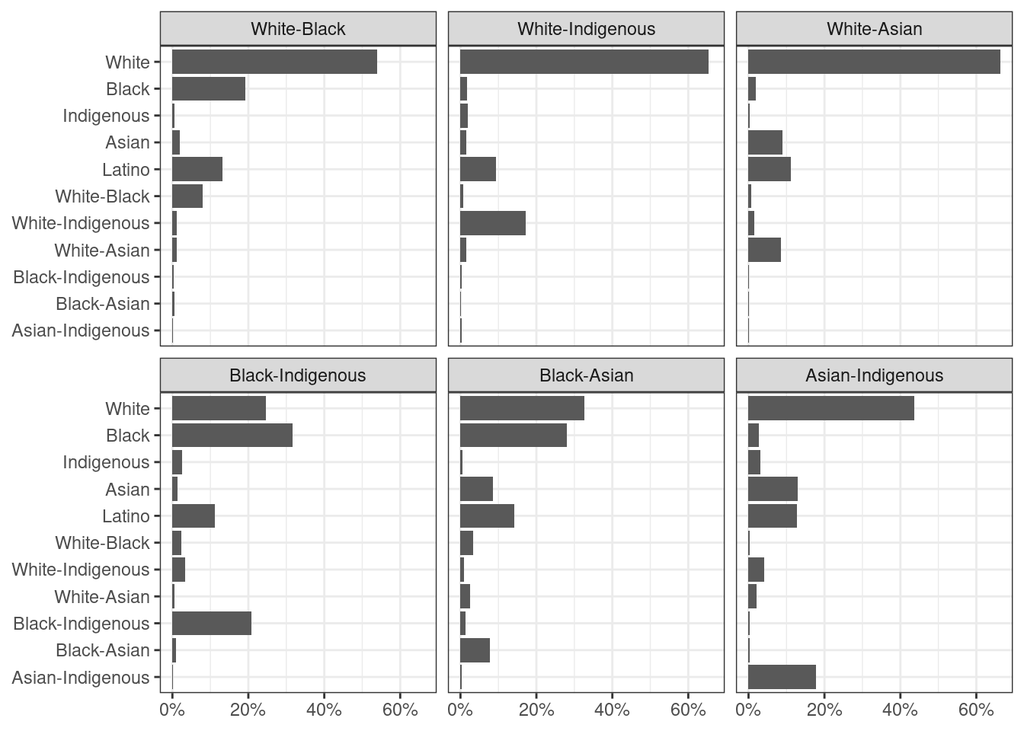

Figure 2: Distribution of partner’s race for multiracial respondents, separately by panel

```r
partner_choice |>
  filter(str_detect(race_ego, "-")) |>
  ggplot(aes(x=fct_rev(race_spouse), y=after_stat(prop), group=1))+
  geom_bar(position="dodge")+
  facet_wrap(~race_ego)+
  scale_y_continuous(labels=scales::percent)+
  scale_color_viridis_d(direction=-1, end=0.75)+
  labs(x=NULL, y=NULL)+
  coord_flip()+
  theme_bw()
```

Two things stand out a little more clearly in Figure 2 here to me:

1. There is a tendency for each constituent group to be higher, although this can be sometimes tricky to see because of group size differences.
2. Latino is high for everybody.

Now lets do this same figure for all racial groups but separately by gender.

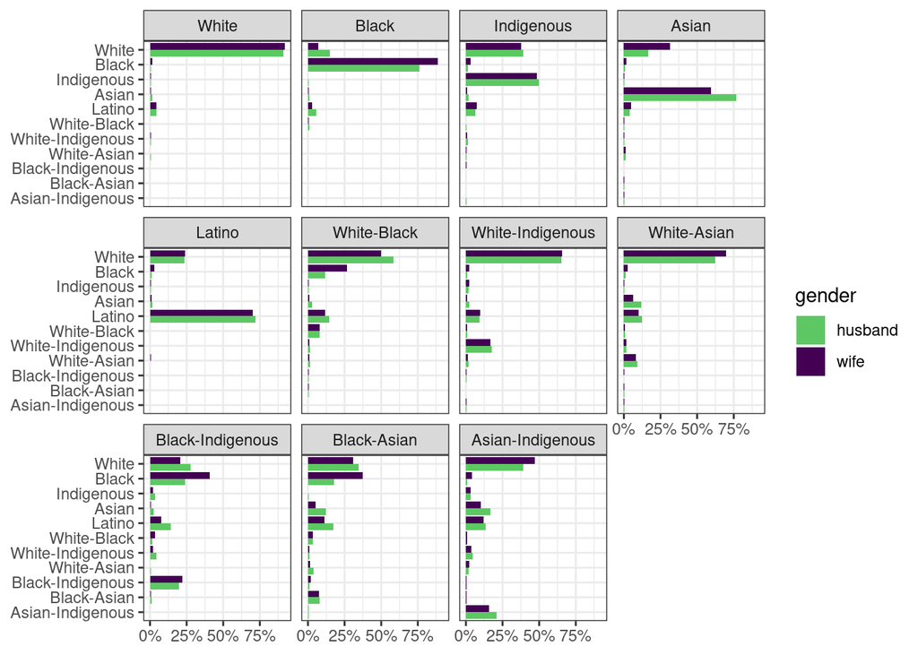

Figure 3: Distribution of partner’s race for all respondents, separately by gender and race of ego respondent

```r
ggplot(partner_choice,
       aes(x=fct_rev(race_spouse), y=after_stat(prop), group=gender, fill=gender))+
  geom_bar(position="dodge")+
  facet_wrap(~race_ego)+
  scale_y_continuous(labels=scales::percent)+
  scale_fill_viridis_d(direction=-1, end=0.75)+
  labs(x=NULL, y=NULL)+
  coord_flip()+
  theme_bw()
```

The data for part-black multiracial individuals are generally consistent with the gender pattern for black individuals - part-Black men are more likely to outmarry, particularly with Whites. For part-Asian individuals who are not also part-Black, the gender pattern seems consistent with that for Asian individuals - women are more likely than men to outmarry with Whites and less likely to marry endogamously. Its notable that the Black/Asian pattern tends to follow the Black pattern. However, its not surprising that Blackness trumps everything else.

I also want to try a panel model that adds some color, although its a little tricky to get conditional distributions in `dplyr`.

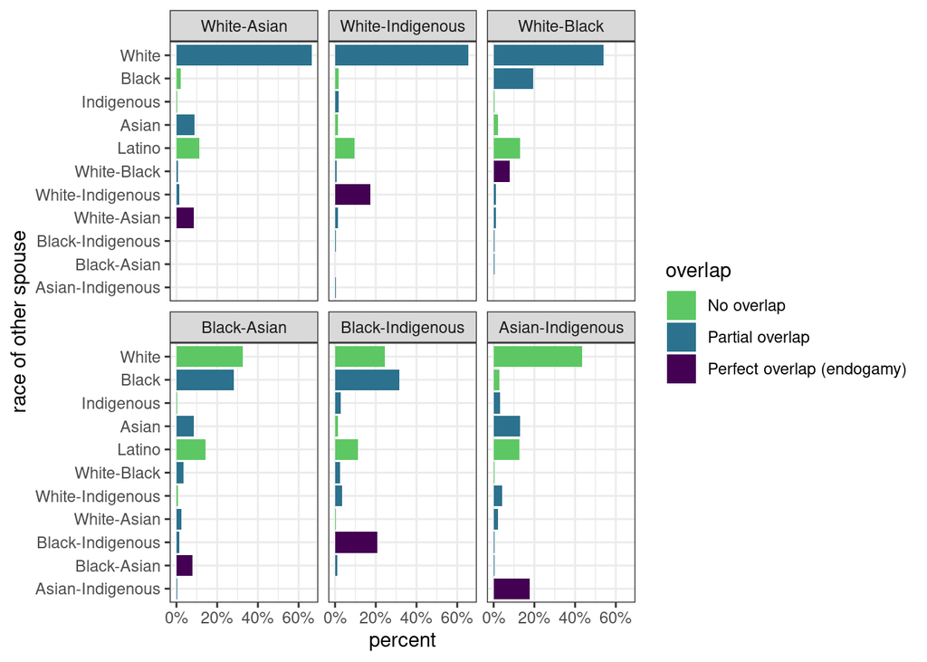

Figure 4: Distribution of partner’s race for multiracial spouses, separately for each multiracial group.

```r
partner_choice |>
  filter(str_detect(race_ego, "-")) |>
  group_by(race_ego, race_spouse) |>
  summarize(n = n()) |>
  pivot_wider(id_cols = race_ego, names_from = race_spouse, values_from = n,
              names_prefix = "n_") |>
  ungroup() %>%
  mutate(total = rowSums(select(., starts_with("n_")))) |>
  pivot_longer(cols=starts_with("n_"), names_prefix="n_", names_to="race_spouse",
               values_to = "n") |>
  mutate(prop = n/total,
         race_ego = as.character(race_ego),
         spouse_multi = str_detect(race_spouse, "-"),
         spouse_const1 = str_split(race_spouse, "-", simplify = TRUE)[,1],
         spouse_const2 = str_split(race_spouse, "-", simplify = TRUE)[,2],
         overlap = case_when(
           race_ego == race_spouse ~ "Perfect overlap (endogamy)",
           !spouse_multi & str_detect(race_ego, race_spouse) ~ "Partial overlap",
           spouse_multi &
             (str_detect(race_ego, spouse_const1) |
                str_detect(race_ego, spouse_const2)) ~ "Partial overlap",
           TRUE ~ "No overlap"
         ),
         overlap = factor(overlap,
                          levels=c("No overlap", "Partial overlap",
                                   "Perfect overlap (endogamy)")),
         race_spouse=factor(race_spouse,
                            levels=c("White","Black","Indigenous","Asian",
                                     "Latino","White-Black","White-Indigenous",
                                     "White-Asian","Black-Indigenous",
                                     "Black-Asian","Asian-Indigenous")),
         race_ego = factor(race_ego,
                           levels = c("White-Asian", "White-Indigenous", "White-Black",
                                      "Black-Asian", "Black-Indigenous", "Asian-Indigenous"))) |>
  ggplot(aes(x = fct_rev(race_spouse), y = prop, fill=overlap))+
  geom_col()+
  facet_wrap(~race_ego)+
  scale_fill_viridis_d(direction = -1, end=0.75)+
  scale_y_continuous(labels = scales::percent)+
  coord_flip()+
  labs(x="race of other spouse", y="percent")+
  theme_bw()
```

# Multiracial-to-multiracial intermarriage

Ok, now lets move to the actual model results. The first thing we want to explore is multiracial-to-multiracial intermarriage. To analyze this, we use a model that fits gender-symmetric dummies for every single multiracial-to-multiracial exogamous union. This model was difficult to fit on the full data because the size of these cells is so small, resulting in some convergence problems in the model. To resolve this issue, we created separate marriage market data only using multiracial individuals to estimate the full terms. If the models only included the racial exogamy terms, then this model would give use identical results to a model with the full data. However, because we will get slightly different estimates on the control variables in this model versus the full model, the results will differ slightly. However, they should be sufficiently close to allow us to determine a more reduced form multiracial-to-multiracial coding we can use in the full data models.

Figure 5 below shows the odds ratios of outmarriage to each other multiracial group for each ego multiracial group, separately by panel.

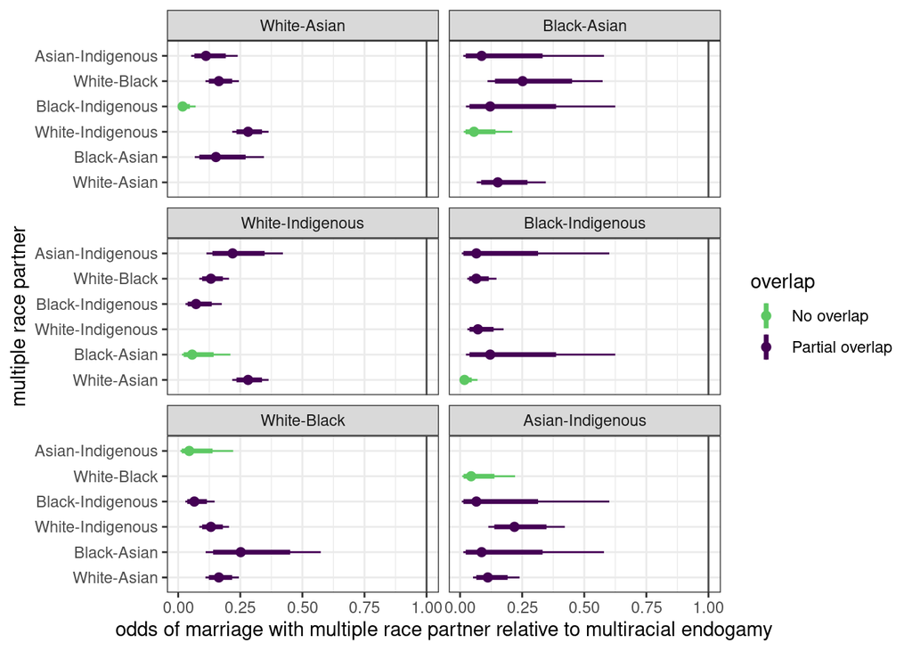

Figure 5: Odds of interracial marriage with other multiracial groups for each multiracial group. The purple dots indicate cases where the ego multiracial group has overlapping partial ancestry with the other multiracial group, while the green dots indicate cases where is no overlap. 83.4% and 95% confidence intervals are shown for each estimate with thick and thin bars, respectively. The grey line indicates the case of an odds equal to one, meaning this type of intermarriage is as likely as endogamy (e.g. White/Black person marrying White/Black person).

```r
# the somewhat odd regular expression \\..*/ will identify all the names with a
# period followed by some characters followed by a forward slash. This will give
# me all cases of a single race/multiple race marriage
temp <- coef_full |>
  filter(str_detect(variable, "-.*\\.*-")) |>
  mutate(race_ego=str_split(variable, "\\.", simplify=TRUE)[,1],
         race_choice=str_split(variable, "\\.", simplify=TRUE)[,2],
         race_cons1=str_split(race_ego, "-", simplify=TRUE)[,1],
         race_cons2=str_split(race_ego, "-", simplify=TRUE)[,2],
         overlap=str_detect(race_choice, race_cons1) |
           str_detect(race_choice, race_cons2),
         overlap = factor(overlap,
                              levels = c(FALSE, TRUE),
                              labels = c("No overlap", "Partial overlap"))) |>
  select(race_ego, race_choice, overlap, coef, se)

# this needs to be duplicated so that each possibility is both ego and choice.
# easiest way to do this is to create a second one, flip the variables and
# bind them together
temp2 <- temp
temp <- temp2 |>
  mutate(race_ego=temp$race_choice,
         race_choice=temp$race_ego) |>
  bind_rows(temp) |>
  mutate(race_ego=factor(race_ego,
                         levels=c("White-Asian","Black-Asian",
                                  "White-Indigenous","Black-Indigenous",
                                  "White-Black","Asian-Indigenous")),
         race_choice=factor(race_choice,
                         levels=c("White-Asian","Black-Asian",
                                  "White-Indigenous","Black-Indigenous",
                                  "White-Black","Asian-Indigenous")))


ggplot(temp, aes(x=race_choice, y=exp(coef), color=overlap))+
  geom_linerange(linewidth=1.25,
                 aes(ymax=exp(coef+1.386*se), ymin=exp(coef-1.386*se)))+
  geom_linerange(linewidth=0.5,
                 aes(ymax=exp(coef+1.96*se), ymin=exp(coef-1.96*se)))+
  geom_point(size=2)+
  geom_hline(yintercept=1, linewidth=0.5, color="grey30")+
  coord_flip()+
  facet_wrap(~race_ego, ncol=2)+
  scale_color_viridis_d(direction=-1, end=0.75)+
  labs(x="multiple race partner",
       y="odds of marriage with multiple race partner relative to multiracial endogamy",
       color="overlap")+
  theme_bw()
```

To get another view of the results, lets line them all up from highest to lowest on the same plot.

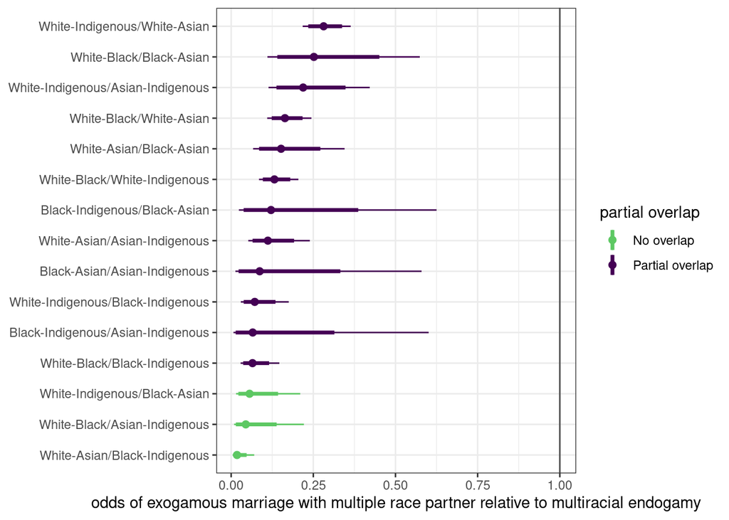

```r
coef_full |>
  mutate(race_ego=str_split(variable, "\\.", simplify=TRUE)[,1],
         race_choice=str_split(variable, "\\.", simplify=TRUE)[,2],
         race_cons1=str_split(race_ego, "-", simplify=TRUE)[,1],
         race_cons2=str_split(race_ego, "-", simplify=TRUE)[,2],
         overlap=str_detect(race_choice, race_cons1) |
           str_detect(race_choice, race_cons2),
         overlap = factor(overlap,
                              levels = c(FALSE, TRUE),
                              labels = c("No overlap", "Partial overlap")),
         variable=str_replace(variable, "\\.","/")) |>
  ggplot(aes(x=reorder(variable, coef, max), y=exp(coef), color=overlap))+
  geom_linerange(linewidth=1.25,
                 aes(ymax=exp(coef+1.386*se), ymin=exp(coef-1.386*se)))+
  geom_linerange(linewidth=0.5,
                 aes(ymax=exp(coef+1.96*se), ymin=exp(coef-1.96*se)))+
  geom_point(size=2)+
  geom_hline(yintercept=1, linewidth=0.5, color="grey30")+
  coord_flip()+
  scale_color_viridis_d(direction=-1, end=0.75)+
  labs(x=NULL,
       y="odds of exogamous marriage with multiple race partner relative to multiracial endogamy",
       color="partial overlap")+
  theme_bw()
```

The three non-overlapping cases are at the bottom, although Black/Indigenous+Indigenous/Asian is also there (with huge error bars). A simple way to reduce the terms for this part of the model would just be to separate non-overlapping from overlapping cases, which would reduce us from 15 terms to 2 terms. Although there is some substantial variation in addition to this, I cannot see a simple pattern that could account for it, especially with the error bars.

```r
bic_diff <- mean(model_short_sym_multi$bic) - mean(model_full_sym_multi$bic)
```

To test this out, we tried an alternate model which reduced all of these specific parameters to two parameters: a multiracial-to-multiracial intermarriage with no shared ancestry and a multiracial-to-multiracial intermarriage with shared ancestry. The BIC statistic was -54.3066003 lower in this more parsimonious model indicating a strong preference for this model over the full model. According to this model, the odds relative to endogamy of an interracial marriage with a multiracial partner with partial overlap are 0.193. The corresponding relative odds for a multiracial partner without partial overlap are 0.044. The difference between these two parameters is highly statistically significant. Partial overlap is important, but partial overlap is still far less likely to lead to a union than full overlap.

# Multiracial-to-monoracial intermarriage

Figure 7 shows the odds of intermarriage between each multiracial group and each single race group. For reference, I also draw lines indicating the reduced form odds of intermarriage between multiracial groups (shared vs. no shared ancestry).

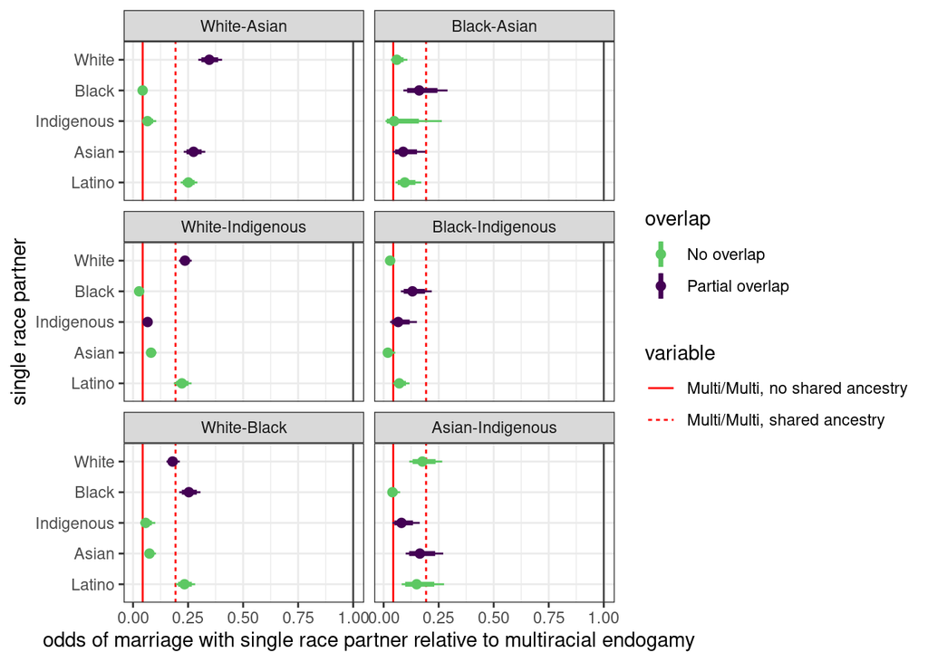

```r
# the somewhat odd regular expression \\..*/ will identify all the names with a
# period followed by some characters followed by a forward slash. This will give
# me all cases of a single race/multiple race marriage
coef_short_sym |>
  filter(str_detect(variable, "\\..*-")) |>
  mutate(single_race=str_split(variable, "\\.", simplify=TRUE)[,1],
         multiple_race=str_split(variable, "\\.", simplify=TRUE)[,2],
         constituent=str_detect(multiple_race, single_race),
         single_race=factor(single_race,
                            levels=c("Latino","Asian","Indigenous",
                                     "Black","White")),
         multiple_race=factor(multiple_race,
                              levels=c("White-Asian","Black-Asian",
                                       "White-Indigenous","Black-Indigenous",
                                       "White-Black","Asian-Indigenous")),
         constituent = factor(constituent,
                              levels = c(FALSE, TRUE),
                              labels = c("No overlap", "Partial overlap")),
         upper84=exp(coef+1.386*se),
         upper95=exp(coef+1.96*se),
         lower84=exp(coef-1.386*se),
         lower95=exp(coef-1.96*se)) |>
  ggplot(aes(x=single_race, y=exp(coef), color=constituent))+
  geom_hline(data=coef_multi, aes(yintercept=exp(coef), linetype=variable),
             color="red")+
  geom_linerange(linewidth=1.25,
                  aes(ymax=upper84, ymin=lower84))+
  geom_linerange(linewidth=0.5,
                  aes(ymax=upper95, ymin=lower95))+
  geom_point(size=2)+
  geom_hline(yintercept=1, linewidth=0.5, color="grey30")+
  coord_flip()+
  facet_wrap(~multiple_race, ncol=2)+
  scale_color_viridis_d(direction=-1, end=0.75)+
  labs(x="single race partner",
       y="odds of marriage with single race partner relative to multiracial endogamy",
       color = "overlap")+
  theme_bw()
```

A few things I note about Figure 7:

1. Latinos have a high rate of intermarriage with all the multiracial groups. This is not accounted for simply by multiple vs. single race Latinos.
2. Notwithstanding (1), the constituent cases tend of have higher odds. This is most obvious in the case of White/Asian and White/Black partners. The two deviations from this are:
- White/Indigenous - the odds of intermarriage with an Indigenous person are as low as the odds for Blacks and Asians.
- Indigenous/Asians - again the odds of intermarriage with an Indigenous person are relatively low and the odds of intermarriage with a White person is the highest. However, this group is also the noisiest because it is the smallest.
3. For most groups the odds of multiracial-to-multiracial intermarriage with shared ancestry are close to the odds for the highest single race group, but not substantially higher. For White/Asians, they are substantially lower.

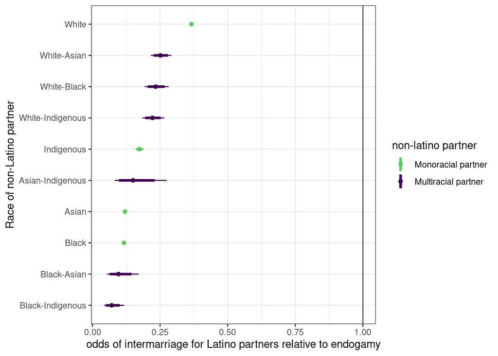

Figure 8: Odds of interracial marriage with single and multiracial race groups for Latinos. The grey line indicates the case of an odds equal to one, meaning this type of intermarriage is as likely as endogamy.

```r
coef_short_sym |>
  filter(str_detect(variable, "Latino")) |>
  mutate(
    variable=str_replace(variable, "Latino",""),
    variable=str_replace(variable, "\\.", ""),
    type=case_when(
      str_count(variable, "-")>0 ~ "Multiracial partner",
      TRUE ~ "Monoracial partner"),
    upper84=exp(coef+1.386*se),
    upper95=exp(coef+1.96*se),
    lower84=exp(coef-1.386*se),
    lower95=exp(coef-1.96*se)) |>
  filter(variable!="") |>
  ggplot(aes(x=reorder(variable, coef, max), y=exp(coef), color=type))+
  geom_hline(yintercept=1, linewidth=0.5, color="grey30")+
  geom_point()+
  geom_linerange(linewidth=1.25,
                  aes(ymax=upper84, ymin=lower84))+
  geom_linerange(linewidth=0.5,
                  aes(ymax=upper95, ymin=lower95))+
  scale_color_viridis_d(direction=-1, end=0.75)+
  labs(x="Race of non-Latino partner",
       y="odds of intermarriage for Latino partners relative to endogamy",
    color="non-latino partner", shape="Latino partner")+
  coord_flip()+
  theme_bw()
```

Aside from intermarriage with whites, Latino intermarriage is more likely to most non-Latino multiracial groups than non-Latino single race groups.

To get at potentially gender differences, Figure 9 displays a similar graph but with separate results depending on the gender combination from a model that allows for gender asymmetry.

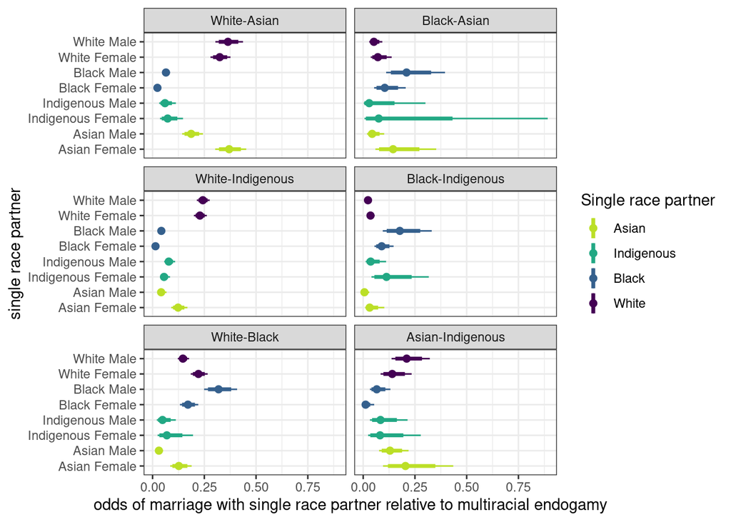

```r
# before period is husband, after period is wife
temp <- coef_short_asym |>
  filter(str_detect(variable, "-") &
           !str_detect(variable, "Multi/Multi|Latino")) |>
  mutate(race_husband=str_split(variable, "\\.", simplify=TRUE)[,1],
         race_wife=str_split(variable, "\\.", simplify=TRUE)[,2],
         race_label=ifelse(str_detect(race_husband, "-"),
                           paste(race_wife, " Female",
                                 sep=""),
                           paste(race_husband, " Male",
                                 sep="")),
         multiple_race=ifelse(str_detect(race_husband, "-"), race_husband,
                            race_wife),
         single_race=ifelse(str_detect(race_husband, "-"), race_wife,
                            race_husband),
         race_group=paste(single_race, ".", multiple_race, sep=""),
         single_race=factor(single_race,
                            levels=c("Latino","Asian","Indigenous",
                                     "Black","White")),
         multiple_race=factor(multiple_race,
                              levels=c("White-Asian","Black-Asian",
                                       "White-Indigenous","Black-Indigenous",
                                       "White-Black","Asian-Indigenous")),
         upper84=exp(coef+1.386*se),
         upper95=exp(coef+1.96*se),
         lower84=exp(coef-1.386*se),
         lower95=exp(coef-1.96*se)) |>
  arrange(multiple_race, single_race, race_label)

temp |>
  ggplot(aes(x=fct_inorder(race_label), y=exp(coef), color=single_race))+
  #geom_hline(yintercept=1, linewidth=0.5, color="grey30")+
  geom_linerange(linewidth=1.25,
                 aes(ymax=upper84, ymin=lower84))+
  geom_linerange(linewidth=0.5,
                 aes(ymax=upper95, ymin=lower95))+
  geom_point(size=2)+
  coord_flip()+
  facet_wrap(~multiple_race, ncol=2)+
  scale_color_viridis_d(direction=-1, end=0.9)+
  theme_bw()+
  labs(color="Single race partner",
       x="single race partner",
       y="odds of marriage with single race partner relative to multiracial endogamy")
```

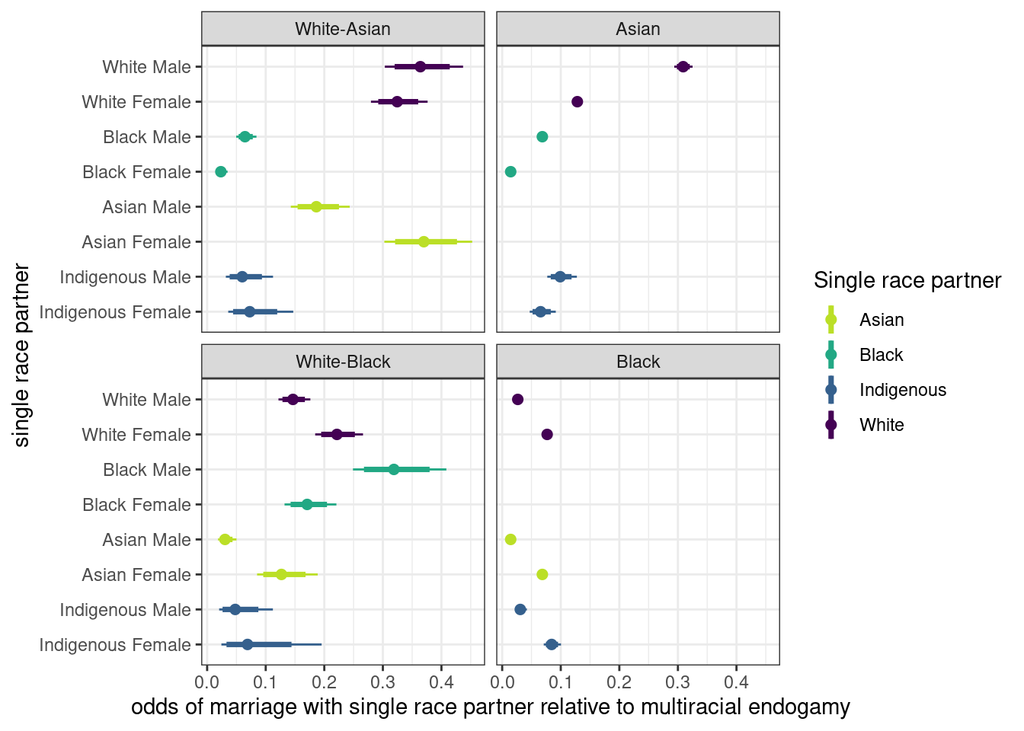

```r
# before period is husband, after period is wife

temp <- coef_short_asym |>
  filter(str_detect(variable, "^Black\\.|\\.Black$") &
           !str_detect(variable, "-") &
           !str_detect(variable, "Multi/Multi|Latino")) |>
  mutate(race_husband=str_split(variable, "\\.", simplify=TRUE)[,1],
         race_wife=str_split(variable, "\\.", simplify=TRUE)[,2],
         ego_race = "Black",
         alt_race = ifelse(str_detect(race_husband, "Black"), race_wife,
                            race_husband),
         race_label=ifelse(str_detect(race_husband, "Black"),
                           paste(race_wife, " Female",
                                 sep=""),
                           paste(race_husband, " Male",
                                 sep="")))

temp <- coef_short_asym |>
  filter(str_detect(variable, "^Asian\\.|\\.Asian$") &
           !str_detect(variable, "-") &
           !str_detect(variable, "Multi/Multi|Latino")) |>
  mutate(race_husband=str_split(variable, "\\.", simplify=TRUE)[,1],
         race_wife=str_split(variable, "\\.", simplify=TRUE)[,2],
         ego_race = "Asian",
         alt_race = ifelse(str_detect(race_husband, "Asian"), race_wife,
                            race_husband),
         race_label=ifelse(str_detect(race_husband, "Asian"),
                           paste(race_wife, " Female",
                                 sep=""),
                           paste(race_husband, " Male",
                                 sep=""))) |>
  bind_rows(temp)

temp <- coef_short_asym |>
  filter(str_detect(variable, "^White-Black\\.|\\.White-Black$") &
           !str_detect(variable, "Multi/Multi|Latino")) |>
  mutate(race_husband=str_split(variable, "\\.", simplify=TRUE)[,1],
         race_wife=str_split(variable, "\\.", simplify=TRUE)[,2],
         ego_race = "White-Black",
         alt_race = ifelse(str_detect(race_husband, "White-Black"), race_wife,
                            race_husband),
         race_label=ifelse(str_detect(race_husband, "White-Black"),
                           paste(race_wife, " Female",
                                 sep=""),
                           paste(race_husband, " Male",
                                 sep=""))) |>
  bind_rows(temp)

temp <- coef_short_asym |>
  filter(str_detect(variable, "^White-Asian\\.|\\.White-Asian$") &
           !str_detect(variable, "Multi/Multi|Latino")) |>
  mutate(race_husband=str_split(variable, "\\.", simplify=TRUE)[,1],
         race_wife=str_split(variable, "\\.", simplify=TRUE)[,2],
         ego_race = "White-Asian",
         alt_race = ifelse(str_detect(race_husband, "White-Asian"), race_wife,
                            race_husband),
         race_label=ifelse(str_detect(race_husband, "White-Asian"),
                           paste(race_wife, " Female",
                                 sep=""),
                           paste(race_husband, " Male",
                                 sep=""))) |>
  bind_rows(temp)

temp <- temp |>
  mutate(upper84=exp(coef+1.386*se),
         upper95=exp(coef+1.96*se),
         lower84=exp(coef-1.386*se),
         lower95=exp(coef-1.96*se),
         ego_race = factor(ego_race,
                           levels = c("White-Asian", "Asian",
                                      "White-Black", "Black")),
         race_label = factor(race_label,
                             levels = c("Indigenous Female", "Indigenous Male",
                                        "Asian Female", "Asian Male",
                                        "Black Female", "Black Male",
                                        "White Female", "White Male")))

temp |>
  ggplot(aes(x=factor(race_label), y=exp(coef), color=alt_race))+
  #geom_hline(yintercept=1, linewidth=0.5, color="grey30")+
  geom_linerange(linewidth=1.25,
                 aes(ymax=upper84, ymin=lower84))+
  geom_linerange(linewidth=0.5,
                 aes(ymax=upper95, ymin=lower95))+
  geom_point(size=2)+
  coord_flip()+
  facet_wrap(~ego_race, ncol=2)+
  scale_color_viridis_d(direction=-1, end=0.9)+
  theme_bw()+
  labs(color="Single race partner",
       x="single race partner",
       y="odds of marriage with single race partner relative to multiracial endogamy")
```

What do we note from Figure 9?

1. For all part-Black individuals, the pattern is like that for single race Black individuals. part-Black male/non-Black female pairings are more likely than vice versa, and correspondingly unions between part-Black female/Black male are more common than vice versa. This is easiest to see for the White/Black case. This implies that with regard to gender dynamics, the one-drop rule operates for people of part-Black ancestry.
2. We don’t really see the same for people of part-Asian ancestry. It is marginally more likely to see White/Asian female+White male pairings than vice versa but the difference is not statistically significant. Furthermore, White/Asians have the same gendered pattern of intermarriage with Asians as other groups - women less likely to marry an Asian male and more likely to marry an Asian female. This suggests more flexibility in how partially Asian people are treated on the marriage market.

# Monoracial-to-monoracial intermarriage

We don’t care as much about the monoracial-to-monoracial comparisons, but lets go ahead and plot those out since we have them.

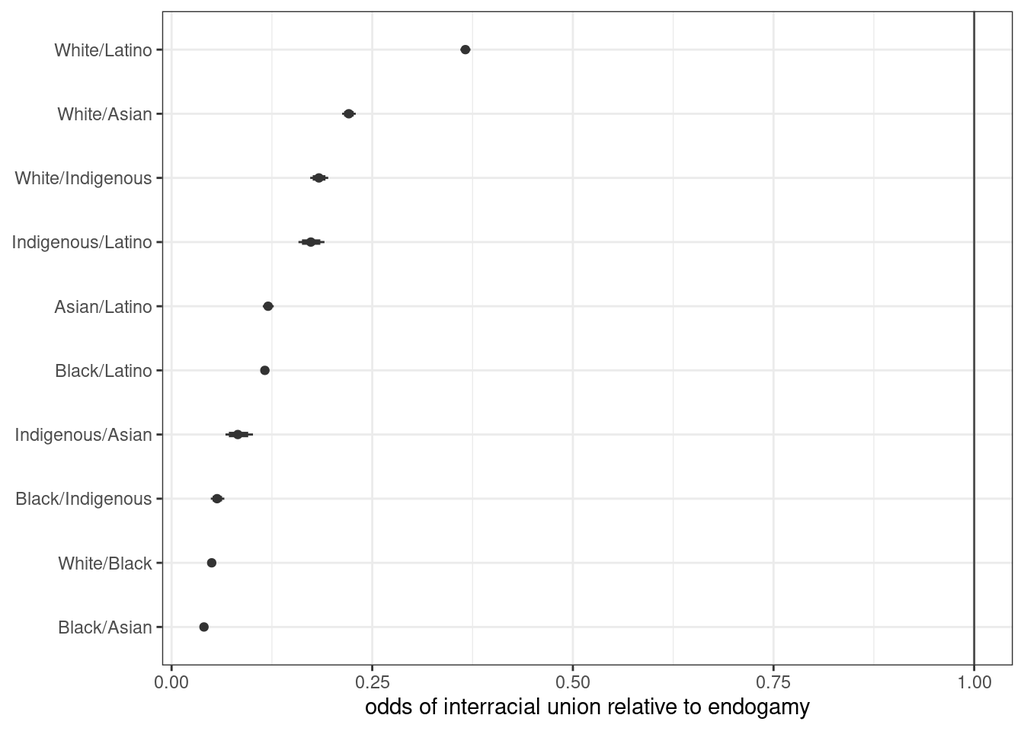

Figure 11: Odds of interracial marriage between single race groups. 83.4% and 95% confidence intervals are shown for each estimate with thick and thin bars, respectively. The grey line indicates the case of an odds equal to one, meaning this type of intermarriage is as likely as endogamy.

```r
coef_short_sym |>
  filter(!str_detect(variable, "-")) |>
  filter(!str_detect(variable, "Multi/Multi")) |>
  mutate(variable=str_replace(variable, "\\.","/"),
         upper84=exp(coef+1.386*se),
         upper95=exp(coef+1.96*se),
         lower84=exp(coef-1.386*se),
         lower95=exp(coef-1.96*se)) |>
  ggplot(aes(x=reorder(variable, coef, max), y=exp(coef)))+
  geom_hline(yintercept=1, linewidth=0.5, color="grey30")+
  geom_linerange(linewidth=1.25, color="grey20",
                 aes(ymax=upper84, ymin=lower84))+
  geom_linerange(linewidth=0.5, color="grey20",
                 aes(ymax=upper95, ymin=lower95))+
  geom_point(color="grey20")+
  coord_flip()+
  theme_bw()+
  labs(x=NULL,
       y="odds of interracial union relative to endogamy")
```

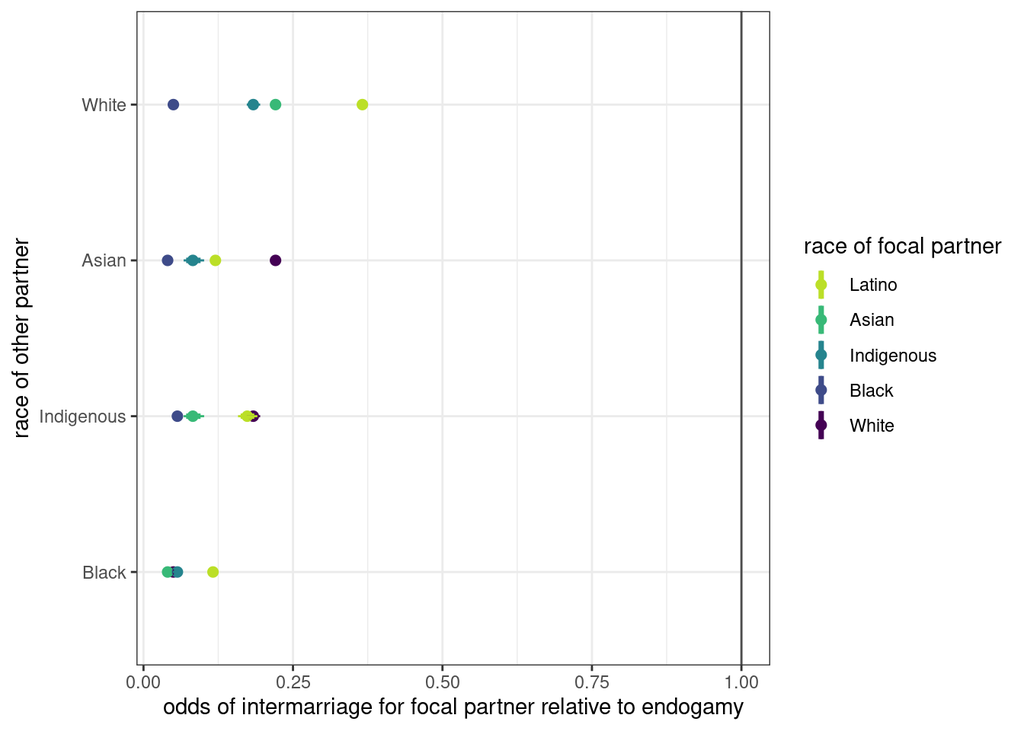

Figure 12: Odds of interracial marriage across all monoracial groups. 83.4% and 95% confidence intervals are shown for each estimate with thick and thin bars, respectively. The grey line indicates the case of an odds equal to one, meaning this type of intermarriage is as likely as endogamy.

```r
temp <- coef_short_sym |>
  filter(!str_detect(variable, "-")) |>
  filter(!str_detect(variable, "Multi/Multi")) |>
  mutate(race1=str_split(variable, "\\.", simplify=TRUE)[,1],
         race2=str_split(variable, "\\.", simplify=TRUE)[,2])

temp <- temp |>
  mutate(race_temp = race1,
         race1 = race2,
         race2 = race_temp) |>
  select(variable, coef, se, race1, race2) |>
  bind_rows(temp) |>
  mutate(upper84=exp(coef+1.386*se),
         upper95=exp(coef+1.96*se),
         lower84=exp(coef-1.386*se),
         lower95=exp(coef-1.96*se))


temp |>
  filter(race1 != "Latino") |>
  mutate(race1 = factor(race1,
                        levels = c("Black", "Indigenous", "Asian", "White")),
         race2 = factor(race2,
                        levels = c("Latino","Asian","Indigenous","Black",
                                   "White"))) |>
  ggplot(aes(x = race1, y = exp(coef), color = race2))+
  geom_hline(yintercept=1, linewidth=0.5, color="grey30")+
  geom_point(size = 2)+
  geom_linerange(linewidth=1.25,
                 aes(ymax=upper84, ymin=lower84))+
  geom_linerange(linewidth=0.5,
                 aes(ymax=upper95, ymin=lower95))+
  scale_color_viridis_d(direction = -1, end = 0.9)+
  labs(x = "race of other partner",
       y = "odds of intermarriage for focal partner relative to endogamy",
       color = "race of focal partner")+
  coord_flip()+
  theme_bw()
```

A few things worth nothing:

1. All of the least likely cases involve a Black partner, except for Black+Latino intermarriage.
2. White/Latino is far the most likely combo, but only for Latino, Single Race.
3. In general, Latino multiple race partners are less exogamous than Latino single race respondents.

For a better comparison across all cases, lets do a megaplot to get everything on the board at once:

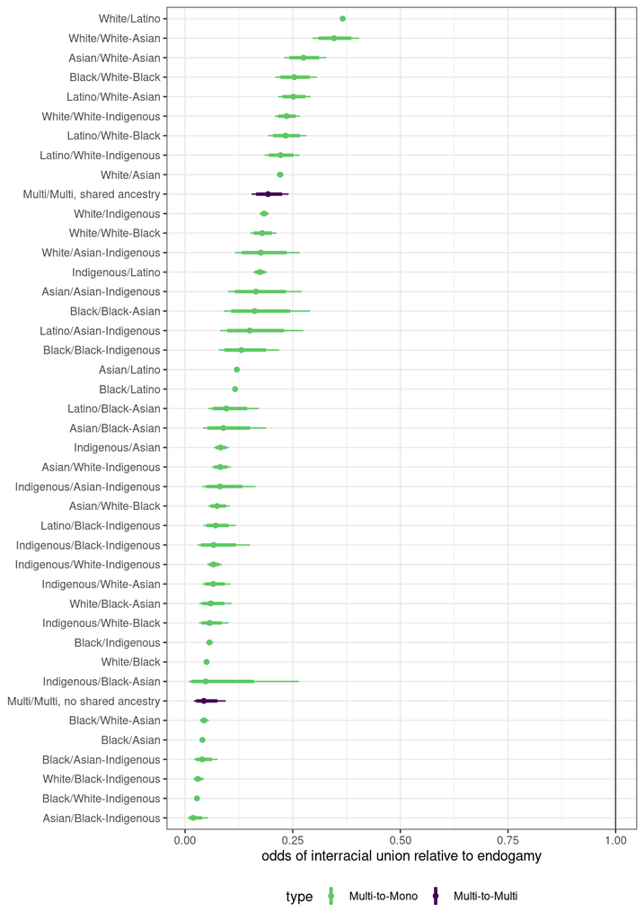

```r
coef_short_sym |>
  mutate(variable=str_replace(variable, "\\.","/"),
         upper84=exp(coef+1.386*se),
         upper95=exp(coef+1.96*se),
         lower84=exp(coef-1.386*se),
         lower95=exp(coef-1.96*se),
         type=case_when(
           str_detect(variable, "Multi/Multi") ~ "Multi-to-Multi",
           str_count(variable, "/")>0 ~ "Multi-to-Mono",
           TRUE ~ "Mono-to-Mono"
         )) |>
  ggplot(aes(x=reorder(variable, coef, max), y=exp(coef), color=type))+
  geom_hline(yintercept=1, linewidth=0.5, color="grey30")+
  geom_linerange(linewidth=1.25,
                 aes(ymax=upper84, ymin=lower84))+
  geom_linerange(linewidth=0.5,
                 aes(ymax=upper95, ymin=lower95))+
  geom_point()+
  coord_flip()+
  scale_color_viridis_d(direction=-1, end=0.75)+
  theme_bw()+
  theme(legend.position = "bottom")+
  labs(x=NULL,
       y="odds of interracial union relative to endogamy")
```

# Full Models

```r
htmlreg(lapply(list(model_full_sym_multi, model_short_sym_multi,
                      model_short_sym, model_short_asym), convertModel),
        digits=3,
        caption=NULL,
        caption.above=TRUE)
```

Table 3: Model predicting union formation

|  | Model 1 | Model 2 | Model 3 | Model 4 |
| --- | --- | --- | --- | --- |
| agediff | 0.062*** | 0.062*** | 0.071*** | 0.071*** |
|  | (0.007) | (0.007) | (0.000) | (0.000) |
| agediff^2 | -0.011*** | -0.011*** | -0.012*** | -0.012*** |
|  | (0.001) | (0.001) | (0.000) | (0.000) |
| hypergamyTRUE | -0.280 | -0.279 | -0.065*** | -0.054*** |
|  | (0.169) | (0.163) | (0.008) | (0.008) |
| hypogamyTRUE | 0.109 | 0.114 | 0.225*** | 0.220*** |
|  | (0.178) | (0.176) | (0.008) | (0.008) |
| edcross_hsTRUE | -0.422* | -0.425* | -0.875*** | -0.879*** |
|  | (0.180) | (0.173) | (0.009) | (0.009) |
| edcross_scTRUE | -0.467*** | -0.458*** | -0.645*** | -0.648*** |
|  | (0.136) | (0.133) | (0.006) | (0.006) |
| edcross_cTRUE | -0.591*** | -0.597*** | -0.749*** | -0.752*** |
|  | (0.126) | (0.126) | (0.007) | (0.007) |
| birth_endogTRUE | 0.463* | 0.483* | 0.440*** | 0.444*** |
|  | (0.221) | (0.220) | (0.010) | (0.011) |
| language_endogTRUE | 1.539*** | 1.514*** | 1.375*** | 1.380*** |
|  | (0.209) | (0.204) | (0.009) | (0.009) |
| race_altWhite-Indigenous | 0.239 | 0.328* | 0.907*** | 0.910*** |
|  | (0.188) | (0.156) | (0.057) | (0.058) |
| race_altWhite-Asian | 0.054 | 0.153 | 0.774*** | 0.777*** |
|  | (0.185) | (0.153) | (0.068) | (0.069) |
| race_altBlack-Indigenous | 1.098* | 0.661** | 1.403*** | 1.396*** |
|  | (0.458) | (0.236) | (0.217) | (0.218) |
| race_altBlack-Asian | 0.779* | 0.875** | 1.623*** | 1.614*** |
|  | (0.330) | (0.275) | (0.313) | (0.311) |
| race_altAsian-Indigenous | 0.550 | 0.566 | 1.122*** | 1.130*** |
|  | (0.420) | (0.332) | (0.235) | (0.241) |
| race_exog_full_symWhite-Black.White-Indigenous | -2.028*** |  |  |  |
|  | (0.225) |  |  |  |

[output cut: 288 more lines]

***p < 0.001; **p < 0.01; *p < 0.05